# Statistical Rethinking Problems: Chapter 3

Simon Thornewill von Essen

2024-03-18

The easy section comes with code for us to check…

```r
p_grid = seq(0, 1, length.out=1000)
prior = rep(1, 1000)
likelihood = dbinom(6, 9, p_grid)
posterior = likelihood * prior / sum(likelihood * prior)

set.seed(100)

samples = sample(p_grid, prob = posterior, size=1e4, replace = TRUE)
```

## 3e1

How much posterior probability lies below `p = 0.2`

```r
mean(samples < 0.2)
```

```
## [1] 4e-04
```

## 3e2

How much posterior probability lies above `p = 0.8`

```r
mean(samples > 0.8)
```

```
## [1] 0.1116
```

## 3e3

How much posterior probability lies beteen `0.2 < p < 0.8`

```r
mean((0.2 < samples) & (samples < 0.8))
```

```
## [1] 0.888
```

## 3e4

20% of the posterior probability lies below which value of p?

```r
quantile(samples, 0.2)
```

```
##       20%
## 0.5185185
```

## 3e5

20% of the posterior probability lies above which value of p?

```r
quantile(samples, 1-0.2)
```

```
##       80%
## 0.7557558
```

## 3e6

Which values of p contain the narrowest interval equal to 66% of the posterior probability?

```r
HPDI(samples, 0.66)
```

```
##     |0.66     0.66|
## 0.5085085 0.7737738
```

## 3e7

Which values of p contain 66% of the posterior probability, assuming equal posterior probability below and above the interval?

```r
PI(samples, 0.66)
```

```
##       17%       83%
## 0.5025025 0.7697698
```

## 3m1

Suppose the globe tossing data had turned out to be 8 water in 15 tosses. Construct the posterior distribution, using grid approximation. Use the same flat prior as before.

```r
p_grid = seq(0, 1, length.out=1000)
prior = rep(1, 1000)
likelihood = dbinom(8, 15, p_grid)
posterior = likelihood * prior / sum(likelihood * prior)
```

## 3m2

Draw 10k samples from the grid approximation from above. Then use the samples to calculate the 90% HPDI for p.

```r
samples = sample(p_grid, prob = posterior, size=1e4, replace = TRUE)

HPDI(samples, 0.9)
```

```
##      |0.9      0.9|
## 0.3293293 0.7167167
```

## 3m3

Construct a posterior predictive check for this model and data. This means simulate the distribution of samples, averaging over the posterior uncertainity in p. What is the probability of observing 8 water in 15 tosses?

```r
post.pred = rbinom(1e4, size=15, prob = samples)

mean(post.pred == 8)
```

```
## [1] 0.1444
```

## 3m4

Using the posterior distribution constructed from the new (8/15) data, now calculate the probability of observing 6 water in 9 tosses.

```r
post.pred = rbinom(1e4, size=9, prob = samples)

mean(post.pred == 6)
```

```
## [1] 0.1751
```

## 3m5

Start over at 3m1, but now use a prior that is zero below 0.5 and constant above 0.5. This corresponds to prior information that the majority of the Earth’s surface is water. Repeat each problem above and compare the inferences. What difference does the better prior make? If it helps, compare inferences (using both priors) to the true value of p=0.7

```r
p_grid = seq(0, 1, length.out=1000)
prior = append(rep(0, 500), rep(1, 500))
likelihood = dbinom(8, 15, p_grid)
posterior = likelihood * prior / sum(likelihood * prior)
```

Here, I use the new prior.

```r
samples = sample(p_grid, prob = posterior, size=1e4, replace = TRUE)

HPDI(samples, 0.9)
```

```
##      |0.9      0.9|
## 0.5005005 0.7117117
```

```r
post.pred = rbinom(1e4, size=15, prob = samples)

mean(post.pred == 8)
```

```
## [1] 0.1589
```

The probability of what we saw is now higher.

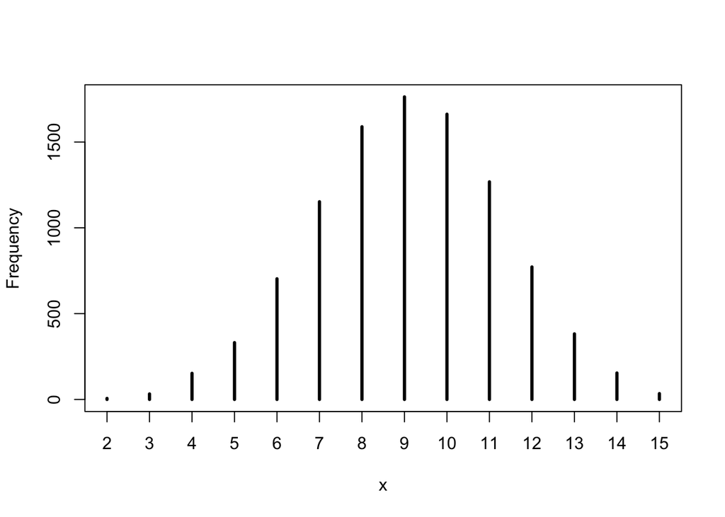

```r
simplehist(post.pred)
```

Just wanted to quickly visualise the posterior predictive distribution.

```r
post.pred = rbinom(1e4, size=9, prob = samples)

mean(post.pred == 6)
```

```
## [1] 0.2415
```

Meanwhile getting a lower value is less likely.

# 3m6

Suppose you want to estimate the Earth’s proportion of water very precisely. Specifically, you want the 99% percentile interval of the posterior distribution of p to be only 0.05 wide. This means the distance between the upper and lower bound of the interval should be 0.05. How many times will you have to toss the globe to do this?

```r
# TODO: Make this code more efficient
df.power = data.frame(
  tosses = seq(100, 5000, 200)
)

PI_lower = rep(1, 25)
PI_upper = rep(1, 25)

p_grid = seq(0, 1, length.out=1000)
prior = rep(1, 1000)

for (i in seq_along(seq(100, 5000, 200))){
  PI_lower.i = rep(0, 1000)
  PI_upper.i = rep(0, 1000)

  for (j in seq(1, 1000)){

    tosses = seq(100, 5000, 200)[i]
    obs = rbinom(1, size = tosses, prob = 0.7)

    likelihood = dbinom(obs, tosses, p_grid)
    posterior = likelihood * prior / sum(likelihood * prior)
    samples = sample(p_grid, prob = posterior, size=1e4, replace = TRUE)
    samples.PI = c(quantile(samples, (0.01)),
                   quantile(samples, 1-(0.01)))


    PI_lower.i[j] = samples.PI[1]
    PI_upper.i[j] = samples.PI[2]
  }
  PI_lower[i] = mean(PI_lower.i)
  PI_upper[i] = mean(PI_upper.i)
}

df.power["PI_lower"] = PI_lower
df.power["PI_upper"] = PI_upper

head(df.power)
```

```
##   tosses  PI_lower  PI_upper
## 1    100 0.5848609 0.7932598
## 2    300 0.6350260 0.7570898
## 3    500 0.6508522 0.7456702
## 4    700 0.6596850 0.7397954
## 5    900 0.6639864 0.7347412
## 6   1100 0.6683658 0.7323588
```

Now, we can visualise the result

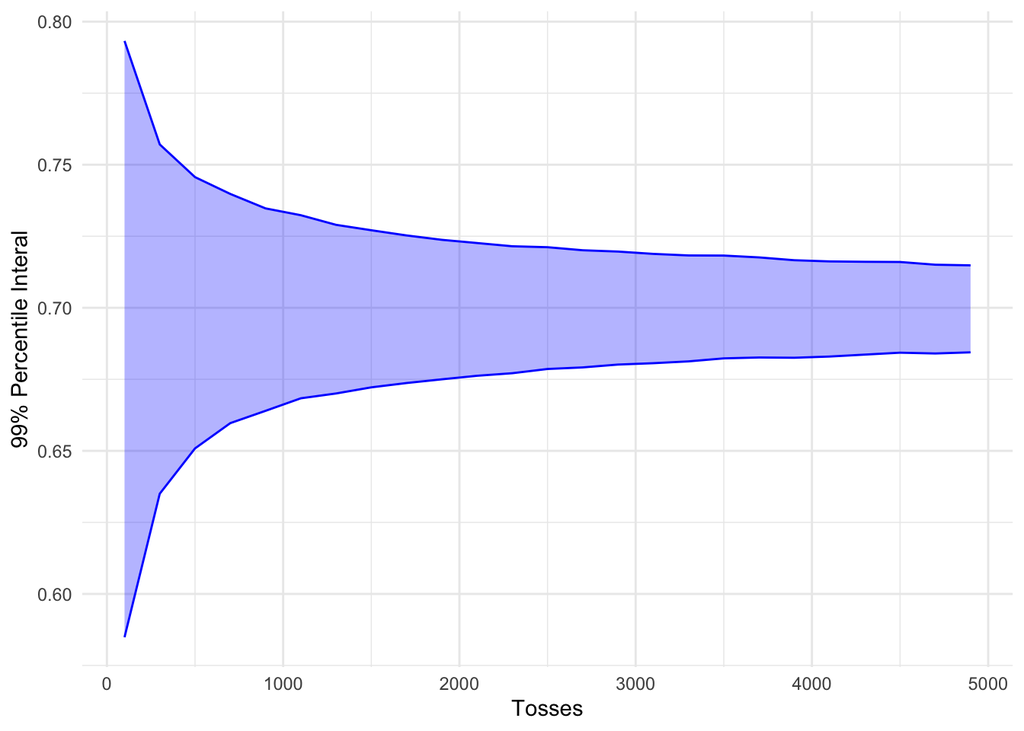

```r
ggplot(df.power, aes(x = tosses)) +
  geom_ribbon(aes(ymin = PI_lower, ymax = PI_upper),
              fill = "blue",
              alpha = 0.3) +
  geom_line(aes(y = PI_lower), color = "blue") +
  geom_line(aes(y = PI_upper), color = "blue") +
  labs(x = "Tosses", y = "99% Percentile Interal") +
  theme_minimal()
```

```r
df.power %>%
  mutate(diff=PI_upper-PI_lower,
         diff_lt_05=diff<0.05) %>%
  filter(diff_lt_05==TRUE) %>%
  summarise(min_tosses=min(tosses))
```

```
##   min_tosses
## 1       1900
```

So, now I’d like to think about how I can make the code more efficient.

- It uses grid approximation to find the posterior, this may look a little different if you were using `quap` or MCMC.
- It’s not that readable
  - Vectors should be named variables
  - Turn tosses into a vector and get out vector of obs
  - Do the 1000 samples at once

```r
tosses_vec = seq(100, 5000, 50)
n.samples = 2000
grid.resolution = 1000

df.power = data.frame(
  tosses = tosses_vec
)

PI_lower = rep(1, length(tosses_vec))
PI_upper = rep(1, length(tosses_vec))

p_grid = seq(0, 1, length.out=grid.resolution)
prior = rep(1, grid.resolution)

for (i in seq_along(tosses_vec)){
  tosses = tosses_vec[i]
  obs = rbinom(n.samples, size=tosses, prob = 0.7)

  likelihoods = outer(obs, p_grid,
                     function(x, p) dbinom(x, size=tosses, prob=p))

  posteriors = likelihoods * t(replicate(n.samples, prior)) /
    rowSums(likelihoods * t(replicate(n.samples, prior)))

  samples = apply(posteriors, 1,
                   function(row_probs) sample(p_grid,
                                              size = 1000,
                                              replace = TRUE,
                                              prob = row_probs))

  samples.PI = apply(samples, 1,
                     function(sample) quantile(sample,
                                               c(0.01, 1-0.01))) %>%
    apply(1, function(x) mean(x))

  PI_lower[i] = samples.PI[1]
  PI_upper[i] = samples.PI[2]
}

df.power["PI_lower"] = PI_lower
df.power["PI_upper"] = PI_upper

head(df.power)
```

```
##   tosses  PI_lower  PI_upper
## 1    100 0.5405658 0.8323994
## 2    150 0.5704368 0.8123151
## 3    200 0.5859184 0.7992325
## 4    250 0.6020316 0.7867741
## 5    300 0.6114169 0.7805779
## 6    350 0.6181269 0.7763474
```

# 3h1

Using grid approximation, compute the posterior distribution for the probability of a birth being a boy. Assume a uniform prior probability. Which parameter value maximizes the posterior probability?

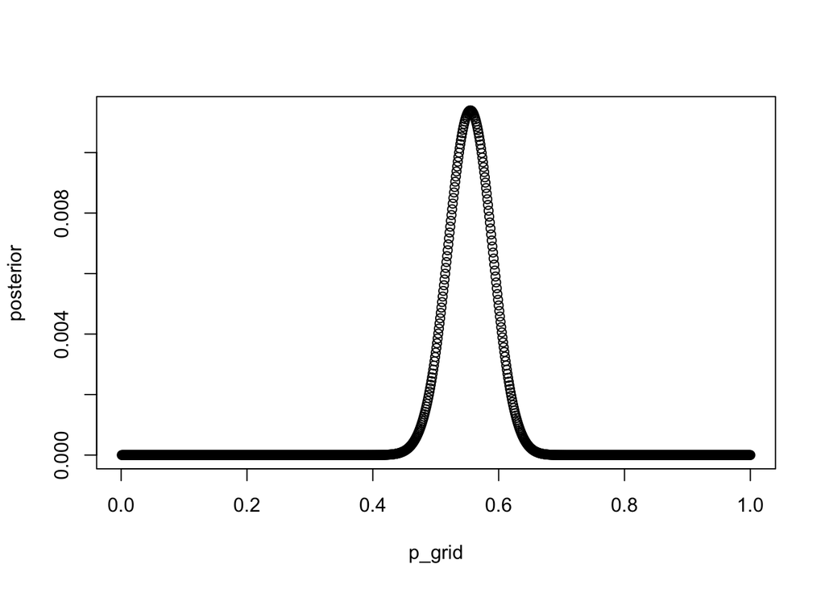

```r
# Data is in birth1 and birth2, which shows two 100 child families
births = append(birth1, birth2)

p_grid = seq(0.001, 1, 0.001)
prior = rep(1, 1000)

n_boys = sum(births)
n_births = length(births)

likelihood = dbinom(x=n_boys, size=n_births, prob=p_grid)
posterior = likelihood * prior / sum(likelihood * prior)

plot(p_grid, posterior)
```

```r
p_grid[which.max(posterior)]
```

```
## [1] 0.555
```

We can see that roughly 55% maximises the posterior.

# 3h2

Using the sample function, draw 10,000 random parameter values from the posterior distribution you calculated above. Use these sample to estimate the 50%, 89%, and 97% highest posterior density intervals.

```r
post.sample = sample(p_grid, size=1e4, replace=TRUE, prob=posterior)

HPDI(post.sample, prob=c(0.5, 0.89, 0.97))
```

```
## |0.97 |0.89  |0.5  0.5| 0.89| 0.97|
## 0.480 0.499 0.531 0.578 0.610 0.629
```

# 3h3

Use rbinom to simulate 10,000 replicates of 200 births. You should end up with 10,000 numbers, each one a count of boys out of 200 births. Compare the distribution of predicted numbers of boys to the actual count in the data (111 boys out of 200 births). There are many good ways to visualize the simulations, but the dens command (part of the rethinking package) is probably the easiest way in this case. Does it look like the model fits the data well? That is, does the distribution of predictions include the actual observation as a central, likely outcome?

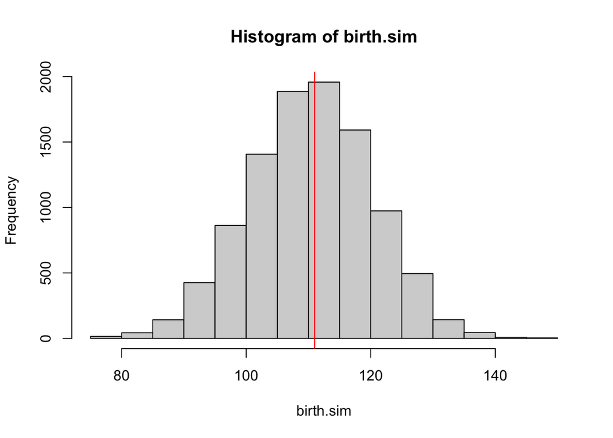

```r
birth.sim = rbinom(size = 200, prob = post.sample, n = 1e4)

hist(birth.sim)
abline(v = 111, col = "red")
```

# 3h4

Now compare 10,000 counts of boys from 100 simulated first-borns, only the number of boys in the first births, birth1. How does the model look in this light?

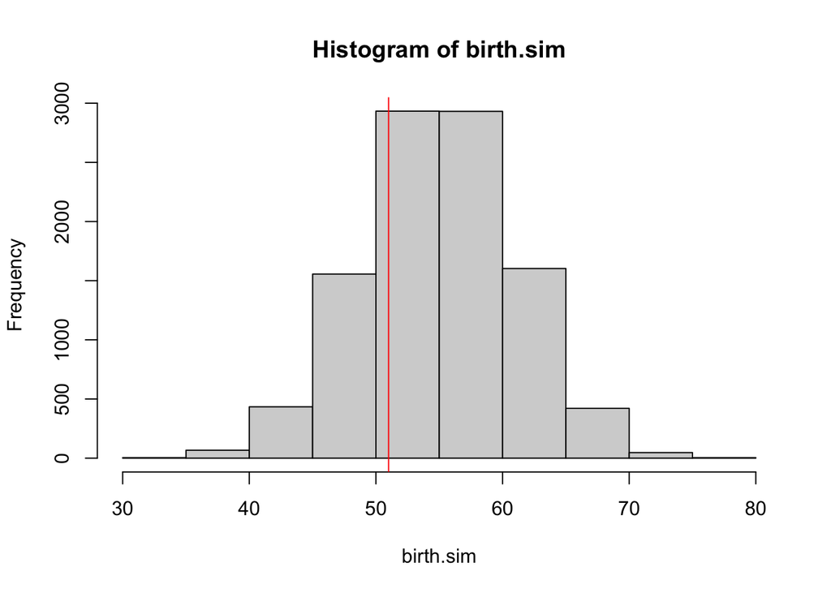

```r
birth.sim = rbinom(size = 100, prob = post.sample, n = 1e4)

hist(birth.sim)
abline(v = sum(birth1), col = "red")
```

# 3h5

The model assumes that sex of first and second births are independent. To check this assumption, focus now on second births that followed female first borns. Compare 10,000 simulated counts of boys to only those second births that followed girls. To do this correctly, you need to count the number of first borns who were girls and simulate that many births, 10,000 times. Compare the counts of boys in your simulations to the actual observed count of boys following girls. How does the model look in this light? Any guesses what is going on in these data?

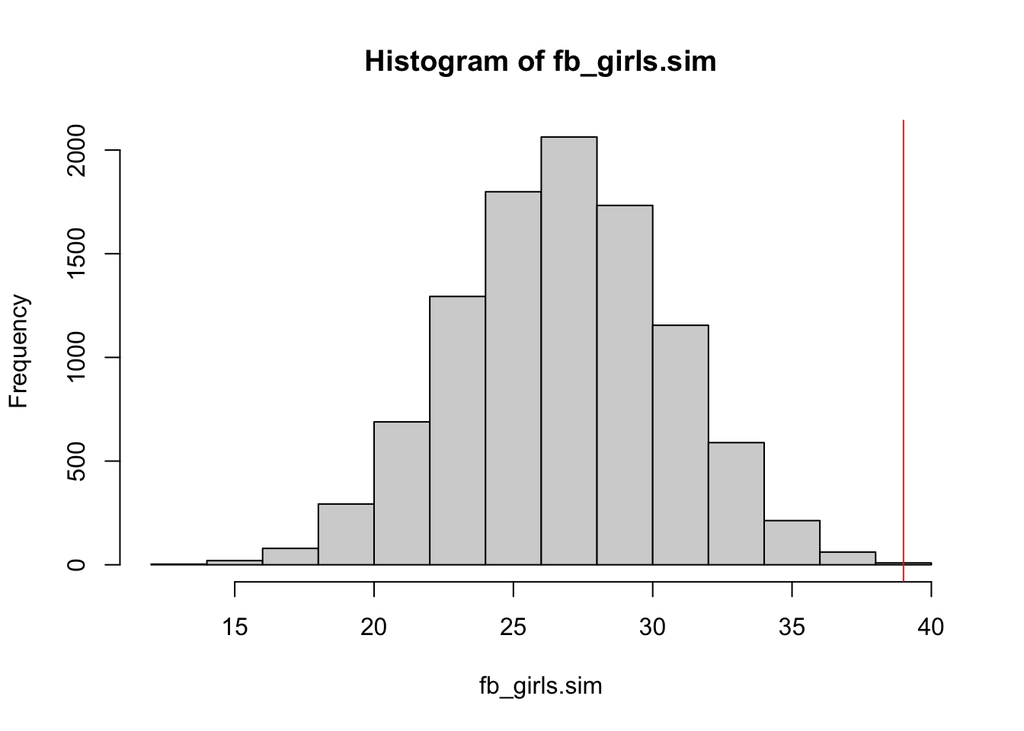

```r
fb_girls = length(birth1) - sum(birth1)

fb_girls.sim = rbinom(1e4, size = fb_girls, prob = post.sample)

obs_bfg = sum(birth2[which(birth1 == 0)])

hist(fb_girls.sim)
abline(v = obs_bfg, col = "red")
```

[output not shown]